# 산업공학특론I_13-14주차_산업데이터분석

2024-05-29

## [데이터 분석 개요]

### 1. 대상 데이터: 다단계 공정 데이터셋

(https://www.kaggle.com/datasets/supergus/multistage-continuousflow-manufacturing-process)

미시간 주 디트로이트 근처의 실제 생산 라인 내에서 여러 위치, 여러 생산 라인에 대하여 계측한 데이터

다양한 입력 데이터로부터 라인의 출력 특정 속성을 예측하기 위한 목적으로 수집

해당 공정 라인은 병렬 및 직렬 단계로 구성된 고속 연속 제조 공정으로, 다음과 같은 구조를 가짐

- Stage 1에서는 M1, M2, M3 기계가 병렬로 작동하며, 이들의 출력이 결합기로 전달
- 결합기에서 출력되는 Stage 1에 대한 예측치는 제작된 제품의 외부 표면을 둘러싼 15개의 위치에서 측정
- 다음으로, M4와 M5가 직렬로 처리하는 Stage 2로 이동
- M5 작동 후에는 동일한 15개의 위치에 대한 Stage 2의 측정이 이루어짐

* Oleghe, O. (2020). A predictive noise correction methodology for manufacturing process datasets. Journal of Big Data, 7(1), 89.

### 2. 분석 절차

데이터 탐색 및 전처리 / 특징 추출 및 차원 축소 / 모델 학습 및 평가 순서로 3단계로 나누어 분석 진행

2단계 공정인 관계로 Stage 1에 대한 예측모델, Stage 2에 대한 예측모델을 2단계로 모델링할 것 (이 때, Stage 2의 결과는 Stage 1에 영향을 받음)

원래 Stage 1, Stage 2에 대한 예측값은 각각 15개씩이지만, 본 강의에서는 다변량 예측을 다루지 않는 관계로 각 Stage에 대한 평균값을 종속변수로 설정

팀별로 작업을 수행하며, 작업 코드는 팀장의 Github에 Push하여 공유, 통찰력 있는 분석 기법 발굴 시 모두와 공유

가이드로 제공된 참고문헌을 바탕으로 다양한 방법론으로 분석을 수행

## [데이터 분석]

### 1. 데이터 탐색 및 전처리

- 데이터의 전반적인 분포, 특징을 파악하기 위한 기초 분석 진행
- 다양한 전처리 방법론을 활용하여 데이터를 정제 (e.g. 필요없는 변수 및 이상치/노이즈 제거 또는 보정, 표준화 등)
- 데이터 전처리 순서 (학습, 테스트셋 분할 전후)를 꼼꼼히 살펴보고 진행할 것

### 2. 특징 추출 및 차원 축소

- 전처리가 이루어진 데이터로부터 특성을 재정의하거나 차원 축소 기법을 적용
- 신규 변수 또는 축소된 차원으로 효과적인 예측을 수행하기 위한 방안 도출

```r
# 데이터 불러오기
train_s1 <- read.csv('train_Stage1.csv')
train_s2 <- read.csv('train_Stage2.csv')
test_s1 <- read.csv('test_Stage1.csv')
test_s2 <- read.csv('test_Stage2.csv')

library(ggplot2)
# Perform PCA
pca_result1 <- prcomp(train_s1, scale. = TRUE)
pca_result2 <- prcomp(train_s2, scale. = TRUE)
pca_result3 <- prcomp(test_s1, scale. = TRUE)
pca_result4 <- prcomp(test_s2, scale. = TRUE)

# Summary of PCA results
summary(pca_result1)
```

```
## Importance of components:
##                           PC1    PC2     PC3     PC4     PC5     PC6     PC7
## Standard deviation     3.5898 2.3840 1.84352 1.54616 1.30616 1.15092 1.06832
## Proportion of Variance 0.3068 0.1353 0.08092 0.05692 0.04062 0.03154 0.02717
## Cumulative Proportion  0.3068 0.4421 0.52307 0.57999 0.62061 0.65215 0.67932
##                            PC8    PC9    PC10    PC11   PC12    PC13    PC14
## Standard deviation     1.04766 1.0143 1.00981 1.00109 0.9913 0.96044 0.94686
## Proportion of Variance 0.02613 0.0245 0.02428 0.02386 0.0234 0.02196 0.02135
## Cumulative Proportion  0.70545 0.7299 0.75423 0.77809 0.8015 0.82345 0.84480
##                           PC15    PC16    PC17    PC18    PC19    PC20    PC21
## Standard deviation     0.91753 0.89596 0.85609 0.82178 0.81427 0.74252 0.70495
## Proportion of Variance 0.02004 0.01911 0.01745 0.01608 0.01579 0.01313 0.01183
## Cumulative Proportion  0.86484 0.88395 0.90140 0.91748 0.93327 0.94639 0.95823
##                           PC22    PC23    PC24    PC25    PC26    PC27    PC28
## Standard deviation     0.60289 0.58241 0.50881 0.40053 0.39103 0.37163 0.30436
## Proportion of Variance 0.00865 0.00808 0.00616 0.00382 0.00364 0.00329 0.00221
## Cumulative Proportion  0.96688 0.97496 0.98112 0.98494 0.98858 0.99187 0.99408
##                           PC29   PC30    PC31    PC32    PC33    PC34   PC35
## Standard deviation     0.24469 0.2154 0.20113 0.17396 0.17007 0.13280 0.1130
## Proportion of Variance 0.00143 0.0011 0.00096 0.00072 0.00069 0.00042 0.0003
## Cumulative Proportion  0.99550 0.9966 0.99757 0.99829 0.99898 0.99940 0.9997
##                           PC36    PC37      PC38      PC39      PC40      PC41
## Standard deviation     0.10794 0.02915 3.869e-14 6.579e-15 1.093e-15 3.311e-16
## Proportion of Variance 0.00028 0.00002 0.000e+00 0.000e+00 0.000e+00 0.000e+00
## Cumulative Proportion  0.99998 1.00000 1.000e+00 1.000e+00 1.000e+00 1.000e+00
##                             PC42
## Standard deviation     3.311e-16
## Proportion of Variance 0.000e+00
## Cumulative Proportion  1.000e+00
```

```r
summary(pca_result2)
```

```
## Importance of components:
##                           PC1    PC2     PC3    PC4     PC5    PC6     PC7
## Standard deviation     4.0030 2.8181 2.12730 1.8346 1.42943 1.3778 1.17929
## Proportion of Variance 0.2862 0.1418 0.08081 0.0601 0.03649 0.0339 0.02483
## Cumulative Proportion  0.2862 0.4280 0.50877 0.5689 0.60536 0.6393 0.66409
##                            PC8     PC9    PC10    PC11    PC12    PC13    PC14
## Standard deviation     1.12836 1.08302 1.07291 1.02965 1.01936 1.01069 1.00205
## Proportion of Variance 0.02274 0.02095 0.02056 0.01893 0.01856 0.01824 0.01793
## Cumulative Proportion  0.68683 0.70777 0.72833 0.74726 0.76582 0.78406 0.80199
##                           PC15    PC16    PC17   PC18    PC19    PC20    PC21
## Standard deviation     0.99231 0.95812 0.95452 0.9196 0.88978 0.86730 0.85389
## Proportion of Variance 0.01758 0.01639 0.01627 0.0151 0.01414 0.01343 0.01302
## Cumulative Proportion  0.81957 0.83596 0.85223 0.8673 0.88147 0.89491 0.90793
##                           PC22    PC23    PC24    PC25    PC26    PC27    PC28
## Standard deviation     0.81673 0.80205 0.78504 0.69143 0.65482 0.60229 0.55634
## Proportion of Variance 0.01191 0.01149 0.01101 0.00854 0.00766 0.00648 0.00553
## Cumulative Proportion  0.91984 0.93133 0.94233 0.95087 0.95852 0.96500 0.97053
##                           PC29    PC30   PC31    PC32    PC33   PC34    PC35
## Standard deviation     0.49675 0.44086 0.4101 0.40229 0.39433 0.3744 0.33228
## Proportion of Variance 0.00441 0.00347 0.0030 0.00289 0.00278 0.0025 0.00197
## Cumulative Proportion  0.97494 0.97841 0.9814 0.98430 0.98708 0.9896 0.99155
##                           PC36    PC37    PC38    PC39    PC40    PC41    PC42
## Standard deviation     0.29814 0.26263 0.25105 0.21680 0.21095 0.19131 0.18423
## Proportion of Variance 0.00159 0.00123 0.00113 0.00084 0.00079 0.00065 0.00061
## Cumulative Proportion  0.99314 0.99437 0.99550 0.99633 0.99713 0.99778 0.99839
##                           PC43    PC44    PC45    PC46    PC47    PC48    PC49
## Standard deviation     0.15095 0.13928 0.12069 0.11527 0.09262 0.09196 0.04889
## Proportion of Variance 0.00041 0.00035 0.00026 0.00024 0.00015 0.00015 0.00004
## Cumulative Proportion  0.99880 0.99914 0.99940 0.99964 0.99979 0.99994 0.99999
##                           PC50      PC51      PC52      PC53      PC54
## Standard deviation     0.02769 3.874e-14 6.567e-15 1.503e-15 1.152e-15
## Proportion of Variance 0.00001 0.000e+00 0.000e+00 0.000e+00 0.000e+00
## Cumulative Proportion  1.00000 1.000e+00 1.000e+00 1.000e+00 1.000e+00
##                             PC55      PC56
## Standard deviation     4.564e-16 3.665e-16
## Proportion of Variance 0.000e+00 0.000e+00
## Cumulative Proportion  1.000e+00 1.000e+00
```

```r
summary(pca_result3)
```

```
## Importance of components:
##                           PC1    PC2     PC3     PC4     PC5     PC6    PC7
## Standard deviation     3.5773 2.3707 1.85842 1.54018 1.30787 1.17410 1.0748
## Proportion of Variance 0.3047 0.1338 0.08223 0.05648 0.04073 0.03282 0.0275
## Cumulative Proportion  0.3047 0.4385 0.52074 0.57722 0.61795 0.65077 0.6783
##                            PC8     PC9    PC10    PC11    PC12    PC13    PC14
## Standard deviation     1.03786 1.02543 1.01057 0.99236 0.98952 0.98390 0.94091
## Proportion of Variance 0.02565 0.02504 0.02432 0.02345 0.02331 0.02305 0.02108
## Cumulative Proportion  0.70392 0.72896 0.75327 0.77672 0.80003 0.82308 0.84416
##                           PC15    PC16    PC17    PC18    PC19    PC20    PC21
## Standard deviation     0.93086 0.90219 0.85189 0.81047 0.79091 0.75503 0.69560
## Proportion of Variance 0.02063 0.01938 0.01728 0.01564 0.01489 0.01357 0.01152
## Cumulative Proportion  0.86479 0.88417 0.90145 0.91709 0.93198 0.94556 0.95708
##                           PC22    PC23    PC24   PC25    PC26    PC27    PC28
## Standard deviation     0.61464 0.59216 0.51626 0.4201 0.38489 0.36517 0.30514
## Proportion of Variance 0.00899 0.00835 0.00635 0.0042 0.00353 0.00317 0.00222
## Cumulative Proportion  0.96607 0.97442 0.98077 0.9850 0.98850 0.99167 0.99389
##                           PC29    PC30   PC31    PC32    PC33    PC34    PC35
## Standard deviation     0.24925 0.21884 0.2046 0.17810 0.16944 0.13561 0.11500
## Proportion of Variance 0.00148 0.00114 0.0010 0.00076 0.00068 0.00044 0.00031
## Cumulative Proportion  0.99537 0.99651 0.9975 0.99826 0.99894 0.99938 0.99970
##                           PC36    PC37      PC38      PC39      PC40      PC41
## Standard deviation     0.10902 0.03008 4.628e-14 3.542e-15 2.567e-15 3.296e-16
## Proportion of Variance 0.00028 0.00002 0.000e+00 0.000e+00 0.000e+00 0.000e+00
## Cumulative Proportion  0.99998 1.00000 1.000e+00 1.000e+00 1.000e+00 1.000e+00
##                            PC42
## Standard deviation     3.04e-16
## Proportion of Variance 0.00e+00
## Cumulative Proportion  1.00e+00
```

```r
summary(pca_result4)
```

```
## Importance of components:
##                           PC1    PC2     PC3     PC4     PC5     PC6     PC7
## Standard deviation     3.9983 2.8044 2.12135 1.85829 1.40697 1.37750 1.18402
## Proportion of Variance 0.2855 0.1404 0.08036 0.06167 0.03535 0.03388 0.02503
## Cumulative Proportion  0.2855 0.4259 0.50626 0.56793 0.60328 0.63716 0.66220
##                           PC8     PC9    PC10    PC11    PC12    PC13    PC14
## Standard deviation     1.1301 1.07735 1.05956 1.04825 1.02758 1.00628 0.99901
## Proportion of Variance 0.0228 0.02073 0.02005 0.01962 0.01886 0.01808 0.01782
## Cumulative Proportion  0.6850 0.70573 0.72577 0.74540 0.76425 0.78233 0.80016
##                           PC15    PC16    PC17    PC18    PC19    PC20    PC21
## Standard deviation     0.98788 0.98022 0.95741 0.94043 0.88958 0.85718 0.84547
## Proportion of Variance 0.01743 0.01716 0.01637 0.01579 0.01413 0.01312 0.01276
## Cumulative Proportion  0.81758 0.83474 0.85111 0.86690 0.88103 0.89415 0.90692
##                          PC22   PC23    PC24    PC25    PC26    PC27    PC28
## Standard deviation     0.8060 0.7885 0.77909 0.69047 0.65996 0.61903 0.56824
## Proportion of Variance 0.0116 0.0111 0.01084 0.00851 0.00778 0.00684 0.00577
## Cumulative Proportion  0.9185 0.9296 0.94046 0.94897 0.95675 0.96360 0.96936
##                           PC29    PC30    PC31    PC32    PC33    PC34    PC35
## Standard deviation     0.51738 0.45711 0.41541 0.40247 0.39414 0.38688 0.33395
## Proportion of Variance 0.00478 0.00373 0.00308 0.00289 0.00277 0.00267 0.00199
## Cumulative Proportion  0.97414 0.97787 0.98095 0.98385 0.98662 0.98929 0.99129
##                           PC36    PC37    PC38    PC39    PC40    PC41    PC42
## Standard deviation     0.30315 0.26036 0.25584 0.22021 0.21590 0.19510 0.18543
## Proportion of Variance 0.00164 0.00121 0.00117 0.00087 0.00083 0.00068 0.00061
## Cumulative Proportion  0.99293 0.99414 0.99531 0.99617 0.99700 0.99768 0.99830
##                           PC43    PC44    PC45    PC46    PC47    PC48    PC49
## Standard deviation     0.15658 0.14341 0.12430 0.11889 0.09486 0.09130 0.05010
## Proportion of Variance 0.00044 0.00037 0.00028 0.00025 0.00016 0.00015 0.00004
## Cumulative Proportion  0.99874 0.99910 0.99938 0.99963 0.99979 0.99994 0.99999
##                           PC50      PC51      PC52      PC53      PC54
## Standard deviation     0.02865 3.752e-14 3.413e-15 2.619e-15 2.442e-15
## Proportion of Variance 0.00001 0.000e+00 0.000e+00 0.000e+00 0.000e+00
## Cumulative Proportion  1.00000 1.000e+00 1.000e+00 1.000e+00 1.000e+00
##                             PC55      PC56
## Standard deviation     3.654e-16 1.764e-16
## Proportion of Variance 0.000e+00 0.000e+00
## Cumulative Proportion  1.000e+00 1.000e+00
```

```r
# PCA scores (principal components)
pca_scores_12 <- pca_result1$x[, 1:12]

colnames(train_s1)
```

```
##  [1] "AmbientConditions_AmbientHumidity"
##  [2] "AmbientConditions_AmbientTemperature"
##  [3] "M1_RawMaterial_Property1"
##  [4] "M1_RawMaterial_Property2"
##  [5] "M1_RawMaterial_Property3"
##  [6] "M1_RawMaterial_Property4"
##  [7] "M1_RawMaterialFeederParameter"
##  [8] "M1_Zone1Temperature"
##  [9] "M1_Zone2Temperature"
## [10] "M1_MotorAmperage"
## [11] "M1_MotorRPM"
## [12] "M1_MaterialPressure"
## [13] "M1_MaterialTemperature"
## [14] "M1_ExitZoneTemperature"
## [15] "M2_RawMaterial_Property1"
```

[output cut: 27 more lines]

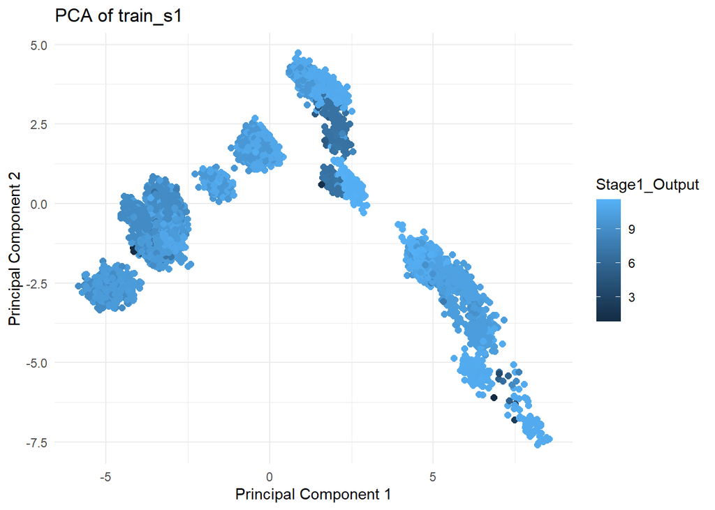

```r
# Add the species column back to the PCA scores for visualization
pca_scores_12 <- data.frame(pca_scores_12, Stage1_Output = train_s1$Stage1_Output)

# Visualize the PCA results
ggplot(pca_scores_12, aes(x = PC1, y = PC2, color = Stage1_Output)) +
  geom_point(size = 2) +
  labs(title = "PCA of train_s1", x = "Principal Component 1", y = "Principal Component 2") +
  theme_minimal()
```

```r
library(caret)
library(e1071)
library(pls)
pca <- preProcess(train_s1[, -ncol(train_s1)], method = 'pca', pcaComp=12)
 trainpca <- predict(pca, train_s1[,-ncol(train_s1)])
 testpca <- predict(pca, test_s1[,-ncol(test_s1)])
 trainpca$Stage1_Output <- train_s1$Stage1_Output
 testpca$Stage1_Output <- test_s1$Stage1_Output
```

### 3. 모델 학습 및 평가

- Stage 1, Stage 2에 대한 예측 모델을 수립할 것
- 이 때, 각 Stage는 연결되어 있으며 Stage 2는 Stage 1의 영향을 받음

```r
# 의사결정나무
library(rpart)
train_control <- trainControl(method = 'cv', number = 10)
rpart_control <- rpart.control(maxdepth=5, minsplit=2)
dt_grid <- expand.grid(.cp = seq(0.01, 0.1, by = 0.01))
dt <- train(Stage1_Output ~ ., data = train_s1, method = 'rpart', trControl = train_control, tuneGrid = dt_grid, control=rpart_control)

dtpca <- train(Stage1_Output ~ ., data = trainpca, method = 'rpart', trControl = train_control, tuneGrid = dt_grid, control=rpart_control)
dtpca
```

```
## CART
##
## 9762 samples
##   12 predictor
##
## No pre-processing
## Resampling: Cross-Validated (10 fold)
## Summary of sample sizes: 8786, 8786, 8787, 8786, 8785, 8786, ...
## Resampling results across tuning parameters:
##
##   cp    RMSE       Rsquared   MAE
##   0.01  0.9529786  0.3347950  0.6584191
##   0.02  0.9554412  0.3316136  0.6683780
##   0.03  0.9933997  0.2772628  0.6714733
##   0.04  1.0304083  0.2204375  0.7131414
##   0.05  1.0591938  0.1777100  0.7467656
##   0.06  1.0780386  0.1471906  0.7564638
##   0.07  1.0780386  0.1471906  0.7564638
##   0.08  1.0780386  0.1471906  0.7564638
##   0.09  1.0780386  0.1471906  0.7564638
##   0.10  1.0780386  0.1471906  0.7564638
##
## RMSE was used to select the optimal model using the smallest value.
## The final value used for the model was cp = 0.01.
```

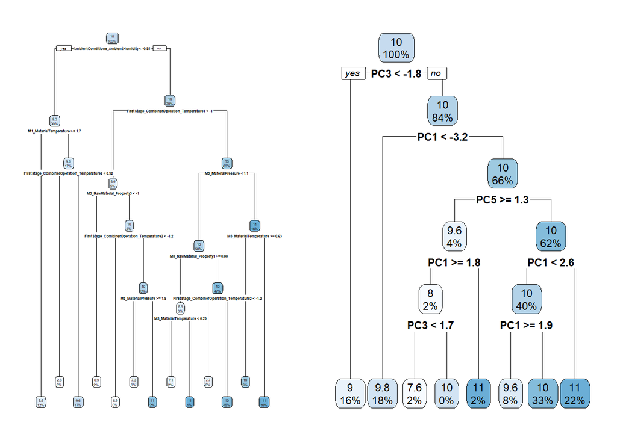

```r
library(rpart.plot)
par(mfrow=c(1,2))
rpart.plot(dt$finalModel)
rpart.plot(dtpca$finalModel)
```

```r
# 다중회귀

reg = lm(Stage1_Output ~ ., data = trainpca)
summary(reg)
```

```
##
## Call:
## lm(formula = Stage1_Output ~ ., data = trainpca)
##
## Residuals:
##     Min      1Q  Median      3Q     Max
## -9.7562 -0.3850  0.1271  0.7351  2.0572
##
## Coefficients:
##              Estimate Std. Error t value Pr(>|t|)
## (Intercept) 10.038015   0.010627 944.588  < 2e-16 ***
## PC1          0.106407   0.002974  35.784  < 2e-16 ***
## PC2          0.013786   0.004458   3.092  0.00199 **
## PC3          0.112380   0.005801  19.373  < 2e-16 ***
## PC4         -0.053243   0.006885  -7.734 1.15e-14 ***
## PC5         -0.163931   0.008289 -19.776  < 2e-16 ***
## PC6         -0.017946   0.009236  -1.943  0.05204 .
## PC7          0.059004   0.010023   5.887 4.06e-09 ***
## PC8          0.115344   0.010277  11.223  < 2e-16 ***
## PC9         -0.034220   0.010487  -3.263  0.00111 **
## PC10         0.014098   0.010526   1.339  0.18047
## PC11         0.004836   0.010616   0.456  0.64876
## PC12         0.053300   0.010756   4.956 7.34e-07 ***
## ---
## Signif. codes:  0 '***' 0.001 '**' 0.01 '*' 0.05 '.' 0.1 ' ' 1
##
## Residual standard error: 1.05 on 9749 degrees of freedom
## Multiple R-squared:  0.1921, Adjusted R-squared:  0.1911
## F-statistic: 193.2 on 12 and 9749 DF,  p-value: < 2.2e-16
```

```r
# 랜덤포레스트
library(randomForest)
rf_model <- randomForest(x = trainpca[,-13], y = trainpca[,13], ntree = 50)
print(rf_model)
```

```
##
## Call:
##  randomForest(x = trainpca[, -13], y = trainpca[, 13], ntree = 50)
##                Type of random forest: regression
##                      Number of trees: 50
## No. of variables tried at each split: 4
##
##           Mean of squared residuals: 0.5561496
##                     % Var explained: 59.19
```